# Spatial and Temporal Continuity at Different Ecological Levels

2024-02-20

## Connectivity

## Why Connectivity

- Fragmentation is one of the main drivers of biodiversity loss
- It diminishes genetic diversity

## Continuous connectivity measures

## Geographic vs continuous connectivity

```r
RasterMaps <- terra::rast(system.file("extdata/covariates.tif", package="GeNetIt"))
data(ralu.site, package="GeNetIt")
sites <- ralu.site
```

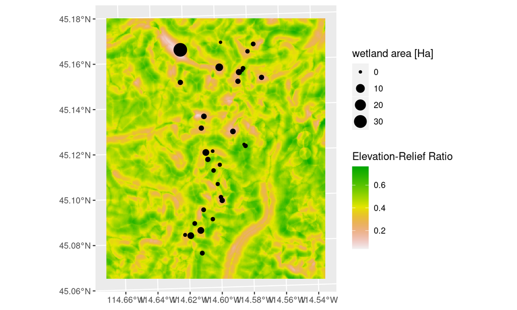

## Variables

Rasters:

- **cti**: Compound Topographic Index (“wetness”)
- **err27**: Elevation Relief Ratio
- **ffp**: Frost Free Period
- **gsp**: Growing Season Precipitation
- **hli**: Heat Load Index
- **nlcd**: USGS Landcover (categorical map)

## Conductance in gDistance

Ranked by experts ordinal 1) cti, 2) gsp, 3) ffp, 4) err27

- *err27*: The elevation relief ratio identifies significant topographic features, higher ERR27 indicate greater topographic change ~ increased resistance. has to be inverted
- *ffp* frost free preriod, the higher the value the more conductivity
- *gsp* Growing Season Precipitation, it has to be more than 196 mm for key species to be present
- *cti* Compound Topographic Index, the higher the more conductivity

```r
err.cost <- (1/RasterMaps[["err27"]])
ffp.cost <- (RasterMaps[["ffp"]]/5)
gsp.cost <- (RasterMaps[["gsp"]]-196)/15
cti.cost <- RasterMaps[["cti"]]/5
cost1 <- (gsp.cost + cti.cost + err.cost + ffp.cost)
```

## conductance and sampling points

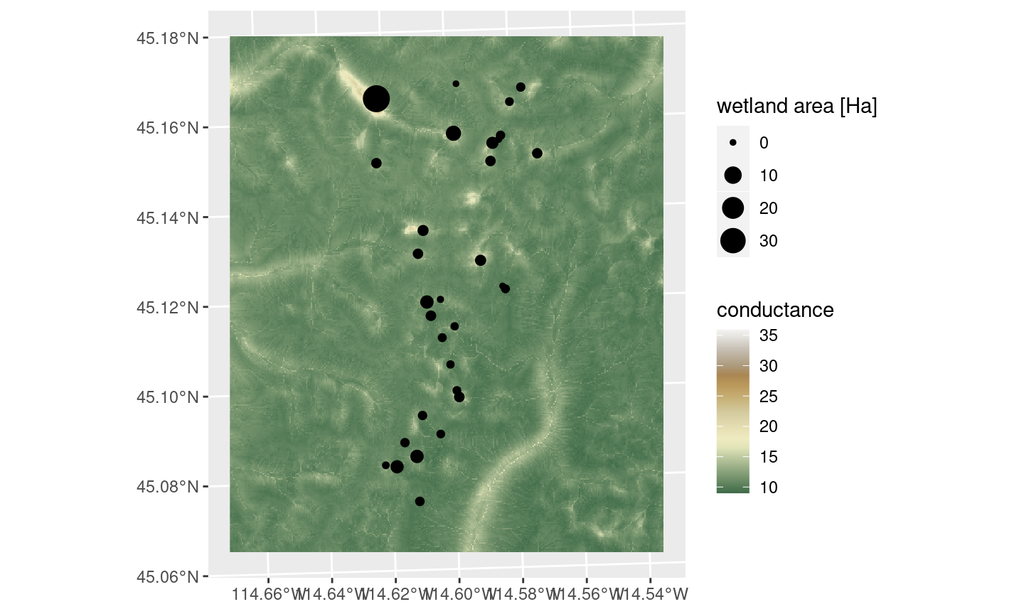

## Generating transition matrices

```r
tr.cost1 <- gdistance::transition(raster::raster(cost1), transitionFunction=mean, directions=8)
tr.cost1 <- gdistance::geoCorrection(tr.cost1,type = "c",multpl=FALSE)
```

## Least cost path vs geographic path

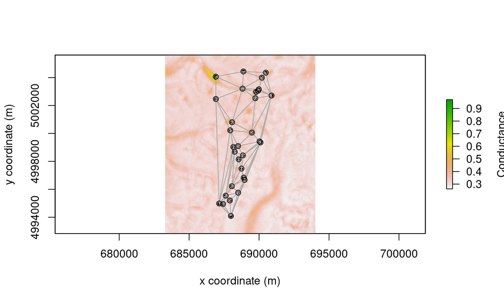

```r
raster::plot(raster::raster(tr.cost1), xlab="x coordinate (m)",
             ylab="y coordinate (m)", legend.lab="Conductance")
points(sites)

Neighbours <- spdep::tri2nb(sf::st_as_sfc(sites), row.names = sites$SiteName)

plot(Neighbours, sf::st_coordinates(sites)
, col="darkgrey", add=TRUE)
```

## Graph based connectivity measures

## How does it work

- We generate a network of patches
- Each patch has attributes (Size, Diversity, Land use, etc)
- Each edge has attributes (Distance, conductivity/resistance)

## Pros and cons

**Pros**

- Computationally eficient
- Robust mathematical framework
- Generating the dataset as a network might not be as easy